# Machine-Learning-Data-Analysis-Graduate-Intern-technical-task

This notebook Walkthroughs my solutin for the regression problem of predicting the percentage of some material properties within a sample. Basically we used the NIR spectral information (our X) to predict some properties percentages (our y).

1- Loading and exploring the data.

2- Preparing the data.

3- Builing and evaluating the model.

## 1- Loading and exploring the data.

The data used here consinsts of 7 NIR tabular datasets that comes from 7 different scanners that measure the same matrial. And a reference sheet with two reference values columns, we only used one of the reference variables.

Now, we import all the neeeded library for this notebook.

```python
#general
import os
from sys import stdout

# data analysis and wrangling
import numpy as np
import pandas as pd

# visualization
import matplotlib.pyplot as plt

# machine learning
from obspy.signal.detrend import polynomial
from sklearn.model_selection import cross_val_predict, cross_val_score , KFold
from sklearn.metrics import r2_score, mean_squared_error
from sklearn.preprocessing import StandardScaler, LabelEncoder
from sklearn.decomposition import PCA
from sklearn.pipeline import make_pipeline, Pipeline
from sklearn.svm import SVR
from sklearn.cross_decomposition import PLSRegression
from sklearn.preprocessing import MinMaxScaler
```

As all the scanners measure the same matrial, We can add them together. But to do so, we first need to check on whether all the scanners operate on the same spectral region and whether or not they have similar readings values.

#### Checking spectral region

```python
data_path = "path to data"
# list all files in the data folder
scanners = os.listdir(f"{data_path}/data")

# get only files starting with 's' or 'S' which referes to scanners
scanners = [name for name in scanners if name[0]=='s' or name[0]=="S"]


all_wavenumbers = []
for filename in scanners:
    if filename.title()[0] == 'S':
        df = pd.read_csv(f"D:\projects/Si-ware/data/{filename}", index_col=None, header=0)
        # drop columns other than wavenumbers
        try:
            df = df.drop(['WVN CM-1', ' '], axis=1)
        except:
            df = df.drop(['WVN CM-1'], axis=1)
        # map wavenumbers from string to float Values
        wavenumbers = map(lambda x : float(x), df.columns)
        all_wavenumbers.append(list(wavenumbers))



all_equal = True
for i in range(len(all_wavenumbers)-1):
    # used "np.allclose" with tolrance of 1 to ignore fractions as our data is in float format
    if not np.allclose(all_wavenumbers[i], all_wavenumbers[i+1], atol=1):
        all_equal = False


print("Do all the scanners operate on the same spectral region?")
print(f"Answer:  {all_equal}.")
```

```
Do all the scanners operate on the same spectral region?
Answer:  True.
```

#### Checking readings values

To do that we used violin plot each scanner dataset and calculate its mean and median values.

```
Scanner 	 mean 	       median  	  min  	      max
1 		 64.63  	65.82     22.11      112.46
2 		 70.51  	71.69     22.78      119.63
3 		 64.08  	65.63     19.53      111.73
4 		 64.24  	65.7     19.6      112.75
5 		 63.11  	64.39     19.72      108.83
6 		 66.37  	67.73     20.73      111.9
7 		 73.46  	74.63     24.93      126.15
```

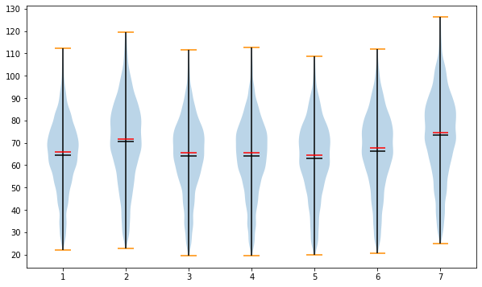

```python
data_path = "D:\projects/Si-ware"
# list all files in the data folder
scanners = os.listdir(f"{data_path}/data")

# get only files starting with 's' or 'S' which referes to scanners
scanners = [name for name in scanners if name[0]=='s' or name[0]=="S"]


all_data = []
for filename in scanners:
    if filename.title()[0] == 'S':
        df = pd.read_csv(f"D:\projects/Si-ware/data/{filename}", index_col=None, header=0)
        try:
            df = df.drop(['WVN CM-1', ' '], axis=1)
        except:
            df = df.drop(['WVN CM-1'], axis=1)
        data = np.array(df).reshape(-1,)
        all_data.append(data)



np.random.seed(42)
plt.figure(figsize = (10, 6))
plt.yticks(range(0, 150, 10))
violin_parts = plt.violinplot(all_data, showmedians=True,
                              showmeans=True)
vbars = violin_parts['cbars']
vbars.set_edgecolor('k')
vmedian = violin_parts['cmedians']
vmedian.set_edgecolor('r')
vmean = violin_parts['cmeans']
vmean.set_edgecolor('k')
vmax = violin_parts['cmaxes']
vmax.set_edgecolor('darkorange')
vmin = violin_parts['cmins']
vmin.set_edgecolor('darkorange')

print("Scanner \t mean \t       median  \t  min  \t      max")
for i in range(len(all_data)):
    print(f"{i+1} \t\t {round(np.mean(all_data[i]), 2)}  \t{round(np.median(all_data[i]), 2)}\
     {round(np.min(all_data[i]), 2)}      {round(np.max(all_data[i]), 2)}")
```

From this plot we can see that all the scanners have similar ranges except for scanner number 7 which have slighly higher values than any other scanner, but those high values still reasonably close to other scanners. So we can assume it's safe to add all the scanners' data together.

We used the 'label id' column to extract sample id and use it to get the reference value from the reference sheet. We used "TLC/SUM" column from the reference sheet as our target added it to our dataframe.

```python
data_path = "D:\projects/Si-ware"
refernce = pd.read_excel(f"{data_path}/data/Reference values_3fills.xlsx")

# list all files in the data folder
scanners = os.listdir(f"{data_path}/data")

# get only files starting with 's' or 'S' which referes to scanners
scanners = [name for name in scanners if name[0]=='s' or name[0]=="S"]

# add all scanners data into single dataframe
all_files = []
for filename in scanners:
    if filename.title()[0] == 'S':
        df = pd.read_csv(f"{data_path}/data/{filename}", index_col=None, header=None)
        all_files.append(df)
data = pd.concat(all_files, axis=0, ignore_index=True)

# set Wavenumbers as colummns names
data.columns = data.iloc[0]

# get rid of any other rows containing Wavenumbers
data = data[data["WVN CM-1"].str.contains("WVN CM-1")==False]

# extract sapmple id from label id
data["Sample ID"] = [int(str(x)[:-1]) for x in data["WVN CM-1"]]

# add target values to our data
data["refernce"] = [refernce["TLC/SUM"][i*3-1] for i in data["Sample ID"]]
```

see how our data look like now.

```python
print('Size of data:',data.shape)
data.head()
```

```
Size of data: (630, 261)
```

|  | WVN CM-1 | 3921.5087890625 | 3935.12533977628 | 3948.74189980328 | 3962.35845051706 | 3975.97501054406 | 3989.59156125784 | 4003.20812128484 | 4016.82467199862 | 4030.44123202562 | ... | 7325.6476316601 | 7339.26418237388 | 7352.88074240088 | 7366.49729311466 | 7380.11385314167 | 7393.73040385544 | 7407.34696388245 |  | Sample ID | refernce |
| --- | --- | --- | --- | --- | --- | --- | --- | --- | --- | --- | --- | --- | --- | --- | --- | --- | --- | --- | --- | --- | --- |
| 1 | 11 | 37.291849 | 36.590000 | 35.927593 | 35.317714 | 34.741831 | 34.161212 | 33.545813 | 32.912391 | 32.353011 | ... | 88.940598 | 90.686373 | 92.269521 | 93.356639 | 93.948836 | 94.319635 | 94.812684 |  | 1 | 20.673077 |
| 2 | 12 | 35.936333 | 35.240853 | 34.586044 | 33.987336 | 33.426477 | 32.862332 | 32.261073 | 31.636413 | 31.079436 | ... | 87.700453 | 89.433000 | 91.027692 | 92.171058 | 92.861619 | 93.347331 | 93.935797 |  | 1 | 20.673077 |
| 3 | 13 | 35.900994 | 35.225520 | 34.584876 | 33.993428 | 33.435553 | 32.874378 | 32.279395 | 31.664813 | 31.119025 | ... | 87.641140 | 89.424907 | 91.043953 | 92.184071 | 92.859401 | 93.343036 | 93.963615 |  | 1 | 20.673077 |
| 4 | 21 | 44.112436 | 43.729980 | 43.343477 | 42.927417 | 42.425208 | 41.747407 | 40.810975 | 39.609078 | 38.274105 | ... | 76.901358 | 79.106777 | 81.261362 | 82.939827 | 84.048671 | 84.786689 | 85.456096 |  | 2 | 36.178862 |
| 5 | 22 | 44.655950 | 44.297054 | 43.923128 | 43.507723 | 42.996876 | 42.305463 | 41.354519 | 40.139741 | 38.794121 | ... | 77.241506 | 79.390399 | 81.496917 | 83.141780 | 84.237164 | 84.985809 | 85.691415 |  | 2 | 36.178862 |

5 rows × 261 columns

Using matplotlib, the spectrums can be plotted

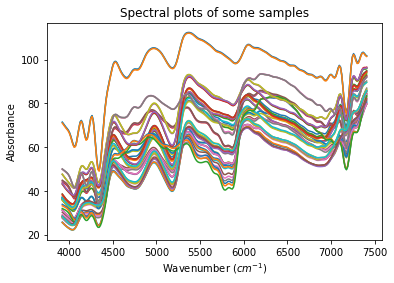

```python
# get Wavenumbers range
Wavenumbers = np.array(data.columns[1:-3])

# get Wavenumbers values only
X = data.drop(['Sample ID','WVN CM-1', ' ', 'refernce'], axis=1)
X = np.array(X)

# plot only 50 rows from the dataset
num_plots = 50
for x in range(num_plots):
    plt.plot(Wavenumbers, X[x,:])

plt.xlabel('Wavenumber ($cm^{-1}$)')
plt.ylabel('Absorbance')
plt.title('Spectral plots of some samples')
plt.show()
```

To have a better understanding of the data and trying to discover if there are any underlying features, We generated a 3D scatter plot of the data. We used PCA with number of components of 3 to be able to plot the data in 3 dimensions.

We divided our data into 5 different categories based on thier reference value:  
["0-10", "10-20", "20-30", "30-40", "40-"]

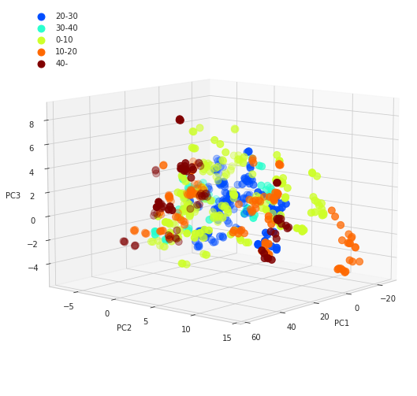

```python
# dvide data into 5 different categories
labels = ["0-10", "10-20", "20-30", "30-40", "40-"]
data["intensity"] = [labels[int(i//10)] if i//10 < 4 else labels[4] for i in data["refernce"]]

# drop catogerical columns to keep only readings values
X = data.drop(['Sample ID','WVN CM-1', ' ', 'refernce', 'intensity'], axis=1)

# PCA decomposition
pca = PCA(n_components=3)
Xpca = pca.fit_transform(StandardScaler().fit_transform(X))

labels = data['intensity']
y = LabelEncoder().fit_transform(labels)

## 3D Scatter plot
unique = list(set(y))
colors = [plt.cm.jet(float(i+1)/(max(unique)+1)) for i in unique]
with plt.style.context(('seaborn-whitegrid')):
    fig = plt.figure(figsize=(10,9))
    ax = fig.add_subplot(111, projection="3d")

    for i, u in enumerate(unique):
        xi = [Xpca[j,0] for j  in range(len(Xpca[:,0])) if y[j] == u]
        yi = [Xpca[j,1] for j  in range(len(Xpca[:,1])) if y[j] == u]
        zi = [Xpca[j,2] for j  in range(len(Xpca[:,2])) if y[j] == u]
        ax.scatter(xi, yi, zi, color=colors[i], s=80, label=str(u))

    ax.view_init(10, 40)

    ax.set_xlabel('PC1')
    ax.set_ylabel('PC2')
    ax.set_zlabel('PC3')

    plt.legend(labels.unique(),loc='upper left')

plt.show()
```

Apperantely, our data is too mixed and there is no trend in it that we can use to get better understanding or better prediction.

## 2- Preparing the data.

Before preprocessing the data, we need to split it into training and testing to prevent any data leakage.

We used the samples with id less 25 to be our training data, and the rest to be our testing data.

```python
train = data[data["Sample ID"] < 25 ]
test = data[data["Sample ID"] >= 25 ]

X_train = train.drop(['Sample ID','WVN CM-1', ' ', 'refernce', 'intensity'], axis=1)
X_test =  test.drop(['Sample ID','WVN CM-1', ' ', 'refernce', 'intensity'], axis=1)

y_train = train['refernce']
y_test = test['refernce']


X_train = np.array(X_train)
X_test = np.array(X_test)
y_train = np.array(y_train)
y_test = np.array(y_test)

print('Size of X train:', X_train.shape)
print('Size of X test:', X_test.shape)
print('Size of y train:', y_train.shape)
print('Size of y test:', y_test.shape)
```

```
Size of X train: (504, 257)
Size of X test: (126, 257)
Size of y train: (504,)
Size of y test: (126,)
```

For preprocessing, We used two different methods:

##### 1- Polynomial detrend + SNV

##### 2- Data augmentation

### 2.1 SNV + polynomial detrend

At this section, We used the Scatter corrections technique to preprocess our data. We preprocessed the data by applying a Standard Normal Variate (SNV) andsecond order polynomial detrend.

The purpose is to remove instrumental noise, and reduce the variance of the spectra from sources such as scatter effect to improve robustness of the model. Here is a quick summary of what these two preprocessing steps are doing:

The "detrend" process fits a curve (in this case a 2nd order polynomial) to the spectra and subtracts it from the spectra. This usually centers the spectra around zero and eliminates small/known spectral distortions.

SNV stands for Standard Normal Variate and consists in finding the mean value for each spectrum and subtract it from the spectrum followed by a division by the standard deviation of that spectrum (i.e. these operations are done on a single spectrum (single row), not over many samples. SNV transforms the data in each spectrum as being centered on zero with std = 1.

For the detrend we used the detrend function implemented by the obspy.signal.detrend package.

This function performs detrend on the data directly (in place). In order to not modify the original data we had to use copy(). Example of detreind a spectrum:

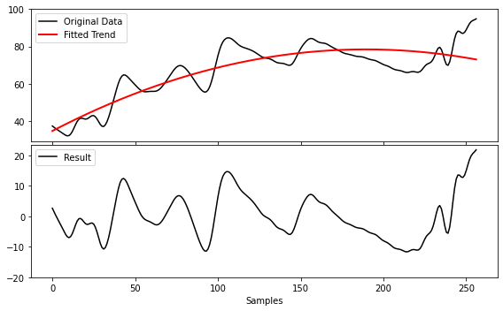

```python
x_sample_detrended = polynomial(X_train[0].copy(),order=2,plot=True)
```

So we had to go sample by sample and perform SNV and followed by detrend correction. We created a couple of functions that loop through all samples.

```python
## Define a function to perform Standard Normal Variate on all spectra
def snv(input_data):
    # Define a new array and populate it with the corrected data
    data_snv = np.zeros_like(input_data)
    for i in range(input_data.shape[0]):
         # Apply correction
        data_snv[i,:] = (input_data[i,:] - np.mean(input_data[i,:])) / np.std(input_data[i,:])
    return data_snv

## Define a function detrend all spectra
def det(input_data):
    data_det = np.zeros_like(input_data)
    for i in range(input_data.shape[0]):
        # Apply detrend
        data_det[i,:] = polynomial(input_data[i,:].copy(), order=2, plot=False)
    return data_det
```

Performing detrending followed by SNV was not recommended by Barnes et al. [Standard Normal Variate Transformation and De-trending of Near-Infrared Diffuse Reflectance Spectra](https://journals.sagepub.com/doi/abs/10.1366/0003702894202201), So we applied SNV followed by detrending.

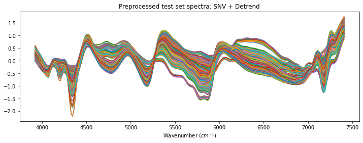

```python
## Apply SNV and detrend to train and test datasets

x_train_prep = det(snv(X_train)) # apply detrended to SNV signal
x_test_prep = det(snv(X_test))

## Plot SNV+detrent data
plt.figure(figsize=(12,4))
plt.title('Preprocessed test set spectra: SNV + Detrend')
plt.plot(Wavenumbers, x_train_prep.T)
_ = plt.xlabel("Wavenumber ($cm^{-1}$)")
```

### 2.2 Data Augmentation

Instead of correction of the baseline variations we use a special implementation of data augmentation. The idea is to simulate the expected form of irrelevant noise (here baseline offset and slope and overall spectrum intensity), and expect the model to either extract features robust to the variations, or figure out the best corrections during training. This way we can make more efficient use of the labelled dataset. The idea is similar to the image rotations and croppings done in image recognition training.

```python
#Expand dataset, Function also available in ChemUtils
def dataaugment(X, betashift = 0.05, slopeshift = 0.05,multishift = 0.05):
    #Shift of baseline
    #calculate arrays
    beta = np.random.random(size=(X.shape[0],1))*2*betashift-betashift
    slope = np.random.random(size=(X.shape[0],1))*2*slopeshift-slopeshift + 1
    #Calculate relative position
    axis = np.array(range(X.shape[1]))/float(X.shape[1])
    #Calculate offset to be added
    offset = slope*(axis) + beta - axis - slope/2. + 0.5

    #Multiplicative
    multi = np.random.random(size=(X.shape[0],1))*2*multishift-multishift + 1

    X = multi*X + offset

    return X
```

To illustrate what data augmentation does, we augmented the first spectrum.

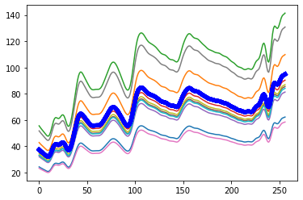

```python
#Data Augment a single spectrum

#First Spectrum
X = X_train[0:1]
#Repeating the spectrum 10x
X = np.repeat(X, repeats=10, axis=0)
#Augment (Large pertubations for illustration)
X_aug = dataaugment(X,betashift = 0.5, slopeshift = 0.5,multishift = 0.5)

plt.plot(X_aug.T)
_= plt.plot(X.T, lw=5, c='b')
```

```
10080
10080
```

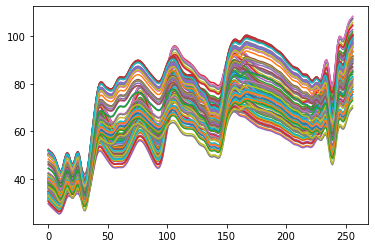

```python
shift = np.std(X_train)*0.01
shift
0.10000000000000003
X_train_aug = np.repeat(X_train, repeats=20, axis=0)
X_train_aug = dataaugment(X_train_aug, betashift = shift, slopeshift = 0.005, multishift = shift)

y_train_aug = np.repeat(y_train, repeats=20, axis=0) #y_train is simply repeated


print (len(X_train_aug))
print (len(y_train_aug))
_ = plt.plot(X_train_aug[0:100].T)
```

## 3- Builing and evaluating the model.

At the heart of all regression methods is the idea of correlating measured spectra of a substance to be analysed, with known reference values of the same substance. In this way one can build a calibration model that ‘translates’ the spectrum into the value of interest. A robust calibration will then enable to obtain the value (or values) of interest straight form the spectra. Here we used **PLS** model. **Partial Least Squares (PLS)** regression is the most widely used technique for developing NIR calibrations.

PLS uses several factors to reach the optimum models which can be helpful in a physical interpretation of the sources of correlation between x and y variables. As NIR data needs to be calibrated against primary reference data of the parameter one seeks to measure, PLS is a good choice.

we want to run a PLS regression with a variable number of components and test its performance in cross-validation. In practice we want to find the number of components that minimises the MSE. We wrote **optimise_pls_cv** function to do that.  
This function first runs a loop over the number of PLS components and calculates the MSE of prediction. Secondly, it finds the number of components that minimises the MSE and uses that value to run a PLS again. A bunch of metrics (**R2 score**, **RMSE** and **Standard deviations of prediction errors(SEP)**) is calculated and printed to evaluate the model with some plots to illustrate the model performance on trainging and testing data.

```python
def optimise_pls_cv(X, y, x_test, y_test,n_comp, plot_components=True):

    '''Run PLS including a variable number of components, up to n_comp,
       and calculate MSE '''

    mse = []
    component = np.arange(1, n_comp)

    for i in component:
        pls = PLSRegression(n_components=i)

        # Cross-validation
        y_cv = cross_val_predict(pls, X, y, cv=5)

        mse.append(mean_squared_error(y, y_cv))

        comp = 100*(i+1)/n_comp
        # Trick to update status on the same line
        stdout.write("\r%d%% completed" % comp)
        stdout.flush()
    stdout.write("\n")

    # Calculate and print the position of minimum in MSE
    msemin = np.argmin(mse)
    print("Suggested number of components: ", msemin+1, "with MSE value of", round(np.min(mse), 2))
    stdout.write("\n")

    if plot_components is True:
        with plt.style.context(('ggplot')):
            plt.plot(component, np.array(mse), '-v', color = 'blue', mfc='blue')
            plt.plot(component[msemin], np.array(mse)[msemin], 'P', ms=10, mfc='red')
            plt.xlabel('Number of PLS components')
            plt.ylabel('MSE')
            plt.title('PLS')
            plt.xlim(left=-1)

        plt.show()

    # Define PLS object with optimal number of components
    pls_opt = PLSRegression(n_components=msemin+1)

    # Fit to the entire dataset
    pls_opt.fit(X, y)
    # use best model on test set
    y_pred = pls_opt.predict(x_test)

    y_c = pls_opt.predict(X)

    # Cross-validation
    y_cv = cross_val_predict(pls_opt, X, y, cv=5)



     ## Compute test error scores
    score_p = r2_score(y_test, y_pred)
    mse_p = mean_squared_error(y_test, y_pred)
    rmse_p = np.sqrt(mse_p)
    sep = np.std(y_test - y_pred)

    ## Compute train error scores
    score_p0 = r2_score(y, y_c)
    mse_p0 = mean_squared_error(y, y_c)
    rmse_p0 = np.sqrt(mse_p0)
    sep0 = np.std(y - y_c)

    print('ERROR METRICS: \t TRAIN \t\t TEST')
    print('--------------------------------------')
    print('R2: \t\t %5.3f \t\t %5.3f'  % (score_p0, score_p ))
    print('RMSE: \t\t %5.3f \t\t %5.3f' % (rmse_p0, rmse_p))
    print('SEP : \t\t %5.3f \t\t %5.3f' % (sep0, sep))

    print(r2_score(pls_opt.predict(x_test), y_test))
    # Fit a line to the training data response
    z = np.polyfit(y, y_c, 1)
    with plt.style.context(('ggplot')):
        fig, ax = plt.subplots(figsize=(9, 5))
        ax.scatter(y_c, y, c='red', edgecolors='k')
        #Plot the best fit line
        ax.plot(np.polyval(z,y), y, c='blue', linewidth=1)
        plt.title('$Training, R^{2}$: '+str(score_p0))
        plt.xlabel('Predicted')
        plt.ylabel('Measured')

        plt.show()

    # Fit a line to the testing data response
    z = np.polyfit(y_test, y_pred, 1)
    with plt.style.context(('ggplot')):
        fig, ax = plt.subplots(figsize=(9, 5))
        ax.scatter(y_pred, y_test, c='red', edgecolors='k')
        #Plot the best fit line
        ax.plot(np.polyval(z,y_test), y_test, c='blue', linewidth=1)
        plt.title('$Testing, R^{2}$: '+str(score_p))
        plt.xlabel('Predicted')
        plt.ylabel('Measured')

        plt.show()
    return pls_opt
```

we ran the function we just defined on the raw data without any preprocessing and got the next results

```
100% completed
Suggested number of components:  15 with MSE value of 12.71
```

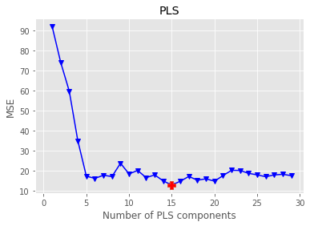

```
ERROR METRICS: 	 TRAIN 		 TEST
--------------------------------------
R2: 		 0.978 		 0.655
RMSE: 		 2.260 		 6.484
SEP : 		 21.567 		 15.267
0.6214798957426197
```

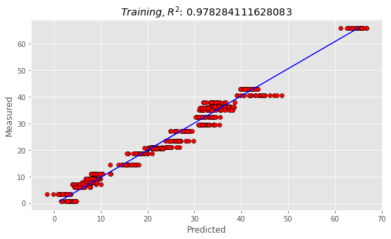

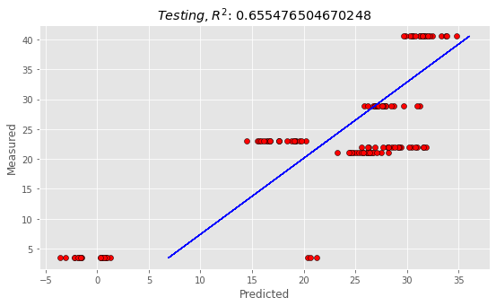

```
PLSRegression(n_components=15)
```

```python
optimise_pls_cv(X_train, y_train, X_test, y_test, 30)
```

we ran optimise_pls_cv function on the preprocessed data using (SNV + Detrend) and got the next results

```
100% completed
Suggested number of components:  12 with MSE value of 10.97
```

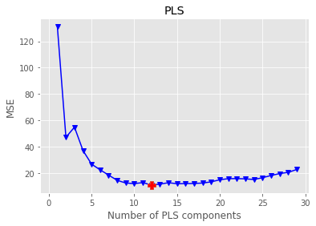

```
ERROR METRICS: 	 TRAIN 		 TEST
--------------------------------------
R2: 		 0.971 		 0.729
RMSE: 		 2.600 		 5.755
SEP : 		 21.529 		 15.291
0.703792593270061
```

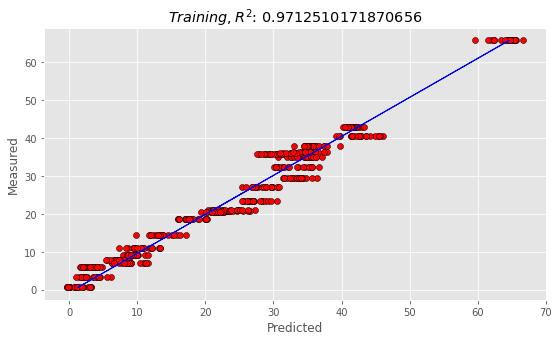

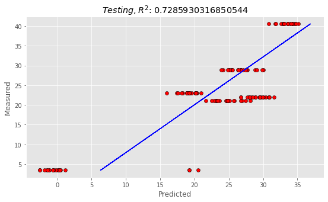

```
PLSRegression(n_components=12)
```

```python
optimise_pls_cv(x_train_prep, y_train, x_test_prep, y_test, 30)
```

Next, we ran **optimise_pls_cv** function on the preprocessed data using data augmentation and got the next results

```
100% completed
Suggested number of components:  10 with MSE value of 11.87
```

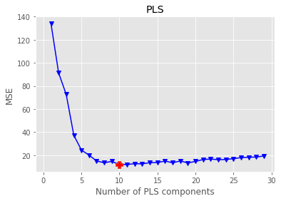

```
ERROR METRICS: 	 TRAIN 		 TEST
--------------------------------------
R2: 		 0.957 		 0.720
RMSE: 		 3.192 		 5.847
SEP : 		 21.449 		 14.512
```

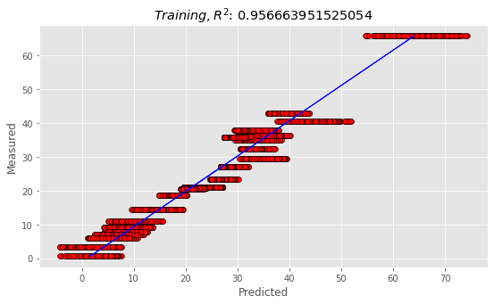

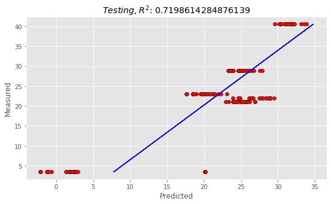

```python
best = optimise_pls_cv(X_train_aug, y_train_aug, X_test, y_test, 30)
```

Preprocessing seems to enhance model performance by at least 6% which is big enhancement. Both models trained on preprocessed data seem to work really well on training data, but not quite as well on the test set. But model trained on data preprocessed using (SNV + detrending) seems to perform a little bit better than the one preprocessed using data augmentation.

### Test-Time Augmentation

Data augmentation is an approach typically used during the training of the model that expands the training set with modified copies of samples from the training dataset. That's why we didn't apply it to test set. But it may be a good idea to try and use it on test data too!

```python
# make a prediction using test-time augmentation
def TTA_prediction(Data, model, n_examples):
    predictions = []
    # Loop over all the passed data
    for sample in Data:
        #Repeating the spectrum
        sample = np.repeat(sample.reshape(1, -1), repeats=n_examples, axis=0)
        # Augmenting the spectrum
        sample_aug = dataaugment(sample,betashift = 0.01, slopeshift = 0.005,multishift = 0.1)
        # make predictions for each augmented spectrum
        y_pred = model.predict(sample_aug)
        # mean of predictions
        m = np.mean(y_pred, axis=0)

        predictions.append(m)

    return np.array(predictions)
```

```python
print(f"Test score using TTA {r2_score(y_test, TTA_prediction(X_test, best, 20))}")
print(f"Test score without using TTA {r2_score(y_test, best.predict(X_test))}")
```

```
Test score using TTA 0.7215491324490562
Test score without using TTA 0.7198614284876139
```

We can notice little improvement in the model performance using TTA. However, it's insignificant improvement.